# Bookbinders: Customer Analysis & Statistical Testing

Deepa Das

# Preliminaries

## Load packages:

```r
library(gmodels)
library(modelr)
library(janitor)
library(haven)
library(readxl)
library(knitr)
library(psych)
library(statar)
library(tidyverse)
library(vip)
library(kelloggmktg482)       # Always load last
```

## Read in the data:

```r
# use load("../data/filename.Rdata") for .Rdata files
load("../data/bbb.Rdata")
```

# Assignment questions and answers

## 1. Previously, you reported the correlation between customers’ total spending on non-book products and on books (see the `nonbook` and `book` variables). Now, report a 95% confidence interval for this correlation.

```r
cor.test(bbb$nonbook,bbb$book)
```

```
##
##  Pearson's product-moment correlation
##
## data:  bbb$nonbook and bbb$book
## t = 35.648, df = 49998, p-value < 2.2e-16
## alternative hypothesis: true correlation is not equal to 0
## 95 percent confidence interval:
##  0.1488761 0.1659721
## sample estimates:
##       cor
## 0.1574359
```

```r
# The correlation co-efficient is 0.1574
# 95 % confidence interval is 0.1488 to 0.1659
```

## 2. Report the output of a linear regression predicting customers’ total spending on non-book products from their spending on book products as well as 95% confidence intervals for the intercept and slope.

```r
lin_reg<-lm(formula=nonbook~book,data=bbb)
# View regression output
summary(lin_reg)
```

```
##
## Call:
## lm(formula = nonbook ~ book, data = bbb)
##
## Residuals:
##      Min       1Q   Median       3Q      Max
## -168.985  -75.382   -0.253   75.190  164.199
##
## Coefficients:
##              Estimate Std. Error t value Pr(>|t|)
## (Intercept) 144.47388    0.61572  234.64   <2e-16 ***
## book          0.36331    0.01019   35.65   <2e-16 ***
## ---
## Signif. codes:  0 '***' 0.001 '**' 0.01 '*' 0.05 '.' 0.1 ' ' 1
##
## Residual standard error: 86.98 on 49998 degrees of freedom
## Multiple R-squared:  0.02479,    Adjusted R-squared:  0.02477
## F-statistic:  1271 on 1 and 49998 DF,  p-value: < 2.2e-16
```

```r
# Get 95% confidence intervals for intercept and slope
confint(lin_reg)
```

```
##                   2.5 %      97.5 %
## (Intercept) 143.2670547 145.6807102
## book          0.3433358   0.3832878
```

```r
#The estimate for intercept and slope are 144.47388 and 0.36331
#the 95% confidence interval for intercept is 143.2670547 145.6807102
#the 95% confidence interval for slope is 0.3433358   0.3832878
```

## 3. Previously, you reported the proportion of customers by gender who bought “The Art History of Florence” (see the `buyer` variable). Now, report a 95% confidence interval for the difference in the proportion of buyers between genders.

```r
library(dplyr)

counts <- table(bbb$gender, bbb$buyer)
buyers <- counts[,"1"]
totals <- rowSums(counts)
prop <- prop.test(buyers, totals, correct=FALSE)
prop
```

```
##
##  2-sample test for equality of proportions without continuity correction
##
## data:  buyers out of totals
## X-squared = 424.02, df = 1, p-value < 2.2e-16
## alternative hypothesis: two.sided
## 95 percent confidence interval:
##  -0.06177431 -0.05023053
## sample estimates:
##     prop 1     prop 2
## 0.07173743 0.12773985
```

```r
prop$conf.int
```

```
## [1] -0.06177431 -0.05023053
## attr(,"conf.level")
## [1] 0.95
```

```r
#95% confidence interval for the difference in the proportion of buyers between genders
#is -0.06177431 to -0.05023053
```

## 4. Report the results of a chi-square test of the association between the state in which the customer lives and whether or the customer bought “The Art History of Florence”.

```r
chisq.test(bbb$state,bbb$buyer,correct=FALSE)
```

```
##
##  Pearson's Chi-squared test
##
## data:  bbb$state and bbb$buyer
## X-squared = 23.549, df = 14, p-value = 0.0519
```

```r
#The chi-squared test result is 23.549 with a p value of 0.0519
#Since p value is greater than 0.05, but very close to 0.05 , it suggests that the reltionship
#between state and whether they bought "The art history of florence" is less statistically significant
#additional analysis may be needed to assess the significance
```

## 5. Report the result of a t-test comparing the average number of purchases by gender as well as a 95% confidence interval for the difference in the average number of purchases between genders.

```r
purch_gender<-t.test(purch~gender,data=bbb,var.equal=TRUE)
print(purch_gender)
```

```
##
##  Two Sample t-test
##
## data:  purch by gender
## t = -49.108, df = 49998, p-value < 2.2e-16
## alternative hypothesis: true difference in means between group F and group M is not equal to 0
## 95 percent confidence interval:
##  -1.644191 -1.517981
## sample estimates:
## mean in group F mean in group M
##        3.362200        4.943287
```

```r
#The mean for females is 3.362200 and the mean for males is 4.943287
# The 95% confidence interval for diferrence in the average number of purchases
#is  -1.644191 -1.517981
```

## 6. Repeat the same analysis but using a linear regression rather than a t-test.

```r
purchase_bygender<-lm(formula(purch~gender),data=bbb)
summary(purchase_bygender)
```

```
##
## Call:
## lm(formula = formula(purch ~ gender), data = bbb)
##
## Residuals:
##    Min     1Q Median     3Q    Max
## -3.943 -2.362 -1.362  2.057  8.638
##
## Coefficients:
##             Estimate Std. Error t value Pr(>|t|)
## (Intercept)  3.36220    0.01861  180.71   <2e-16 ***
## genderM      1.58109    0.03220   49.11   <2e-16 ***
## ---
## Signif. codes:  0 '***' 0.001 '**' 0.01 '*' 0.05 '.' 0.1 ' ' 1
##
## Residual standard error: 3.395 on 49998 degrees of freedom
## Multiple R-squared:  0.04601,    Adjusted R-squared:  0.04599
## F-statistic:  2412 on 1 and 49998 DF,  p-value: < 2.2e-16
```

```r
confint(purchase_bygender)
```

```
##                2.5 %   97.5 %
## (Intercept) 3.325732 3.398668
## genderM     1.517981 1.644191
```

```r
#the null hypothesis is rejected, p value is 2e-16
#there is statistically significant relation between average number ofpurchase
#and gender
```

## 7. In class, we examined a logistic regression predicting the `buyer` variable. In this assigment, we want to predict whether the customer is female versus male. First, we must create `female` binary variable using the following:

```r
bbb <- bbb %>% mutate(female = factor(1 * (gender=="F")))
```

## Before proceeding to fit a logistic regression, first provide graphical evidence that the variables `do_it`, `total`, and `last` are or are not predictive of whether the customer is female versus male.

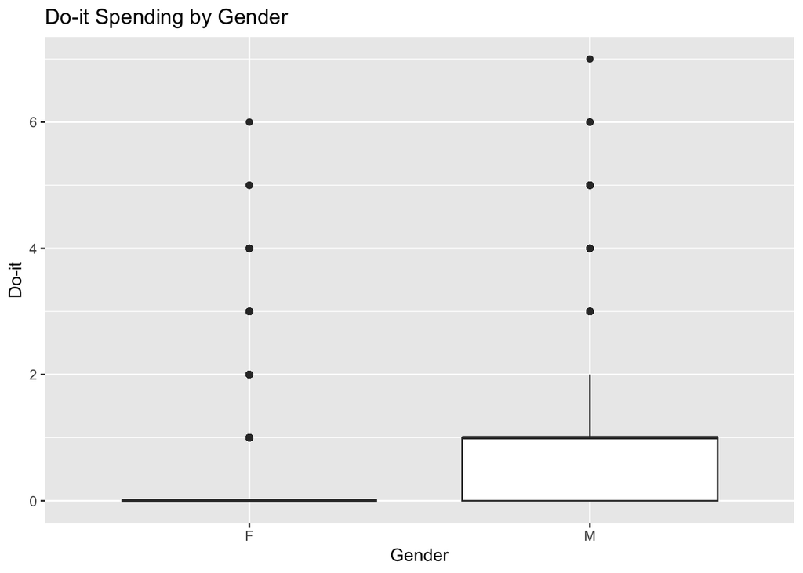

```r
library(tidyverse)

# Boxplot for do_it
ggplot(bbb, aes(x = gender, y = do_it)) +
  geom_boxplot() +
  labs(title = "Do-it Spending by Gender", y = "Do-it", x = "Gender")
```

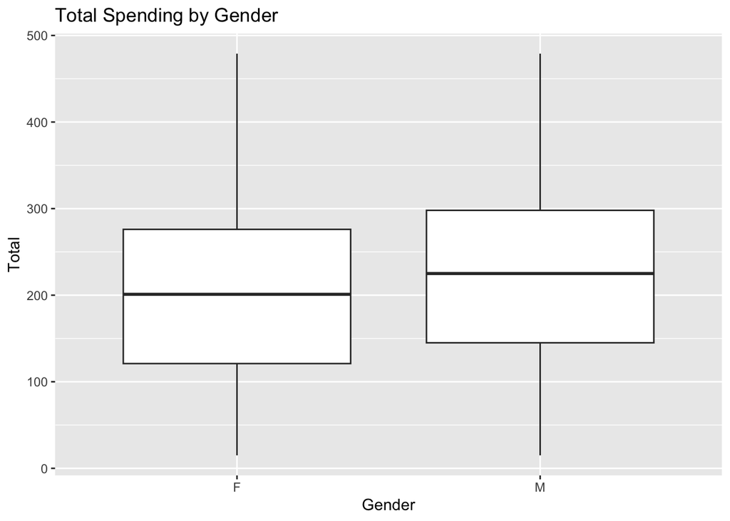

```r
# Boxplot for total spending
ggplot(bbb, aes(x = gender, y = total)) +
  geom_boxplot() +
  labs(title = "Total Spending by Gender", y = "Total", x = "Gender")
```

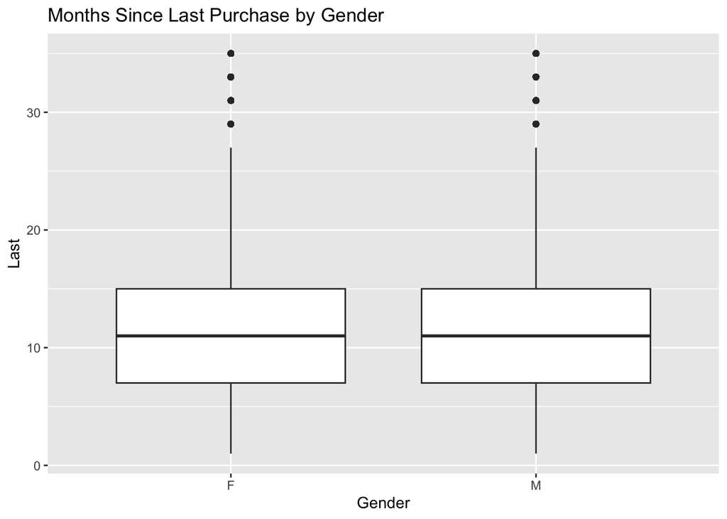

```r
# Boxplot for months since last purchase
ggplot(bbb, aes(x = gender, y = last)) +
  geom_boxplot() +
  labs(title = "Months Since Last Purchase by Gender", y = "Last", x = "Gender")
```

```r
# do_it is a strong predictor: men clearly purchase more DIY books than women.

#total variable:  Male customers have slightly higher median total spending than
#females.The upper quartile for men is slightly more spread out than for women.
#Still, there's a lot of overlap.So this variable is a weak predictor

#The median is about the same for both males and females (~11–12 months).
#The spread is similar for both genders.No meaningful difference in recency of purchase
#between genders.So, 'last' is not a strong predictor of gender.
```

## 8. Report the output of a logistic regression predicting `female` using the variables `last`, `total`, `child`, `youth`, `cook`, `do_it`, `reference`, `art`, and `geog` as well as 95% confidence intervals for the intercept and coefficients.

```r
log_model <- glm(female ~ last + total + child + youth + cook + do_it + reference + art + geog,
                 data = bbb,
                 family = "binomial")
summary(log_model)
```

```
##
## Call:
## glm(formula = female ~ last + total + child + youth + cook +
##     do_it + reference + art + geog, family = "binomial", data = bbb)
##
## Coefficients:
##               Estimate Std. Error z value Pr(>|z|)
## (Intercept)  1.228e+00  2.750e-02  44.660  < 2e-16 ***
## last        -4.903e-04  1.220e-03  -0.402 0.687666
## total        9.244e-05  1.147e-04   0.806 0.420139
## child       -3.582e-02  9.824e-03  -3.646 0.000266 ***
## youth       -1.137e-02  1.525e-02  -0.745 0.456040
## cook        -2.723e-02  9.381e-03  -2.902 0.003704 **
## do_it       -7.634e-01  1.449e-02 -52.705  < 2e-16 ***
## reference   -9.022e-02  1.693e-02  -5.330 9.84e-08 ***
## art         -8.414e-02  1.518e-02  -5.542 3.00e-08 ***
## geog        -7.399e-02  1.257e-02  -5.885 3.97e-09 ***
## ---
## Signif. codes:  0 '***' 0.001 '**' 0.01 '*' 0.05 '.' 0.1 ' ' 1
##
## (Dispersion parameter for binomial family taken to be 1)
##
##     Null deviance: 63695  on 49999  degrees of freedom
## Residual deviance: 59172  on 49990  degrees of freedom
## AIC: 59192
##
## Number of Fisher Scoring iterations: 4
```

```r
confint(log_model)
```

```
##                     2.5 %        97.5 %
## (Intercept)  1.1743287606  1.2821296766
## last        -0.0028786002  0.0019023112
## total       -0.0001322957  0.0003171818
## child       -0.0550592370 -0.0165484898
## youth       -0.0412188342  0.0185575607
## cook        -0.0456007683 -0.0088263990
## do_it       -0.7919158688 -0.7351338708
## reference   -0.1233721473 -0.0570141511
## art         -0.1138816120 -0.0543598240
## geog        -0.0986121712 -0.0493310671
```

```r
#last   - co-efficient is -4.903e-04 and 95% CI is  (-0.0029, 0.0019)
# last is not significant predictor of gender

#total- co-efficient is 9.244e-05 and 95% CI is (-0.00013, 0.00032) 0.420
#total is not significant  predictor of gender

#child- co-efficient is -3.582e-02  and 95% CI is   (-0.055, -0.017)
#significant predictor of female

#youth- co-efficient is -1.137e-02 and 95% CI is    (-0.041, 0.019) 0.456
#youth is not a significant predictor of female

#cook   - co-efficient is -2.723e-02 and 95% CI is  (-0.046, -0.009)
#cook is a significant predictor

#do_it- co-efficient is -7.634e-01 and 95% CI is    (-0.792, -0.735)
#significant predictor

#reference- co-efficient is -9.022e-02 and 95% CI is    (-0.123, -0.057)
#Significant predictor

#art- co-efficient is   -8.414e-02 and 95% CI is    (-0.114, -0.054)
#Significant predictor

#geog- co-efficient is -7.399e-02    and 95% CI is  (-0.099, -0.049)
#Significant predictor

#Summary:The variables, do_it, child, cook, reference, art, and geog, are
#significant predictors of the 'gender' variable, since their p-values are below
#0.05.
```

## 9. Report the variable importance for all variables included in the logistic regression.

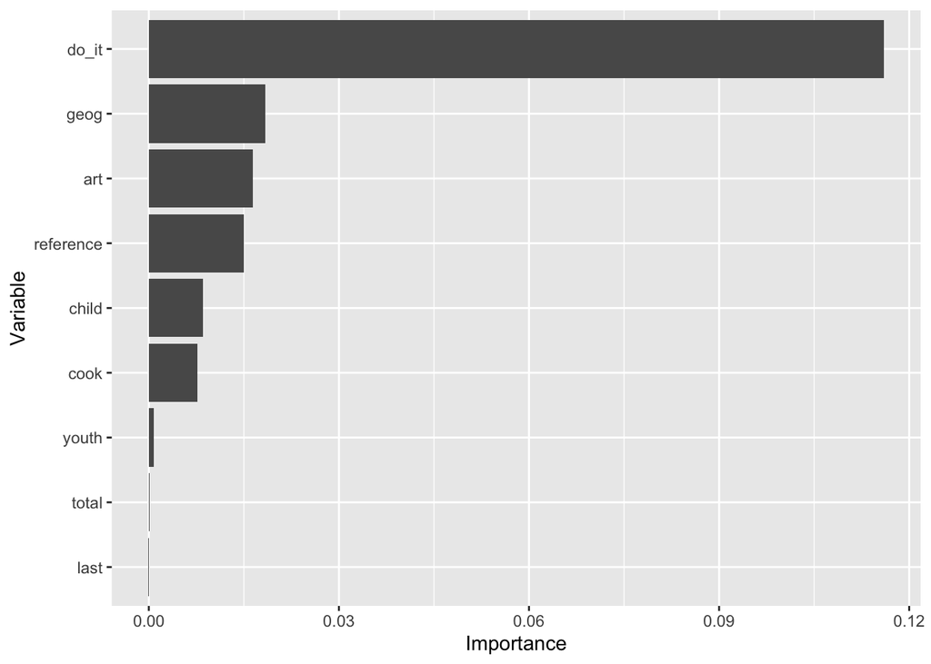

```r
varimpplot(log_model,target="female",data =bbb)
```

```r
#consistent with Question 8 interpretation.The variables, do_it, child, cook,
#reference, art, and geog have impact on the target variable.
#x-axis is in RMSE units
#do_it has approx.11% impact when omitted in the target variable prediction
#geog has  approx.2% impact when omitted in the target variable prediction
#art has  approx.1.7% impact when omitted in the target variable prediction
#reference has  approx.1.6% impact when omitted in the target variable prediction
#child has  approx.0.75% impact when omitted in the target variable prediction
#cook has  approx.0.6% impact when omitted in the target variable prediction
#youth has  approx.0% impact when omitted in the target variable prediction
#last has  approx.0% impact when omitted in the target variable prediction
#total has  approx.0% impact when omitted in the target variable prediction
```

## 10. Report partial dependence plots for all variables included in the logistic regression. Comment on whether the partial dependence plots for `do_it`, `total`, and `last` are consistent or inconsistent with those you found in Question 7 and explain any consistency or inconsistency.

```r
female.overall<-mean(bbb$female)
```

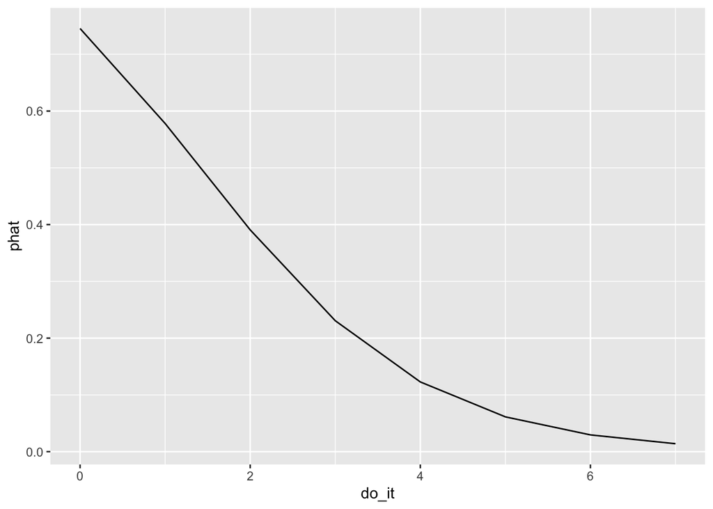

```r
pardepplot(log_model,pred.var="do_it",data=bbb,hline=female.overall)
```

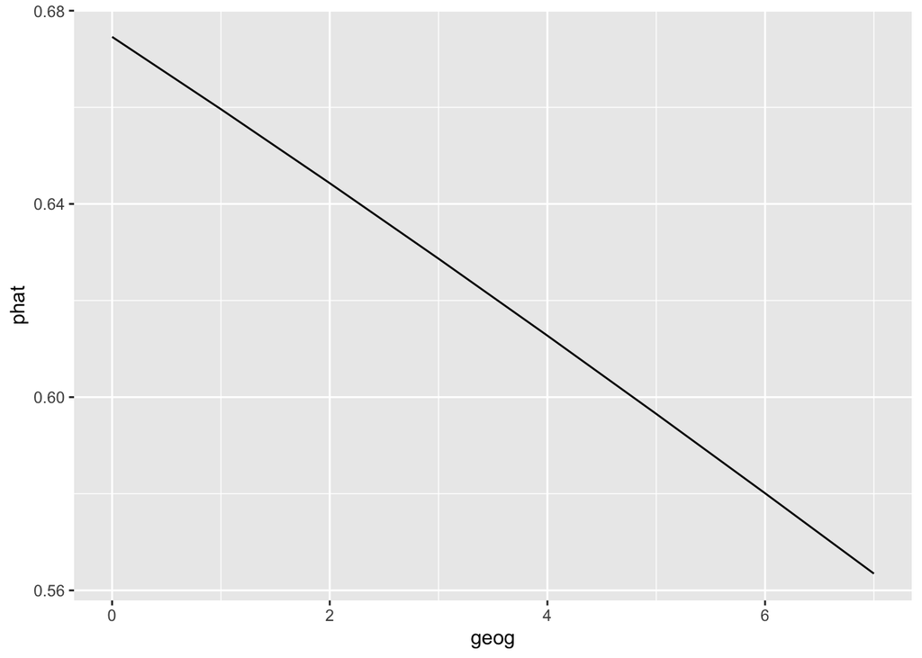

```r
pardepplot(log_model,pred.var="geog",data=bbb,hline=female.overall)
```

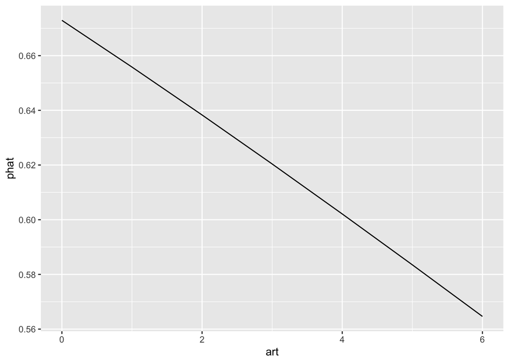

```r
pardepplot(log_model,pred.var="art",data=bbb,hline=female.overall)
```

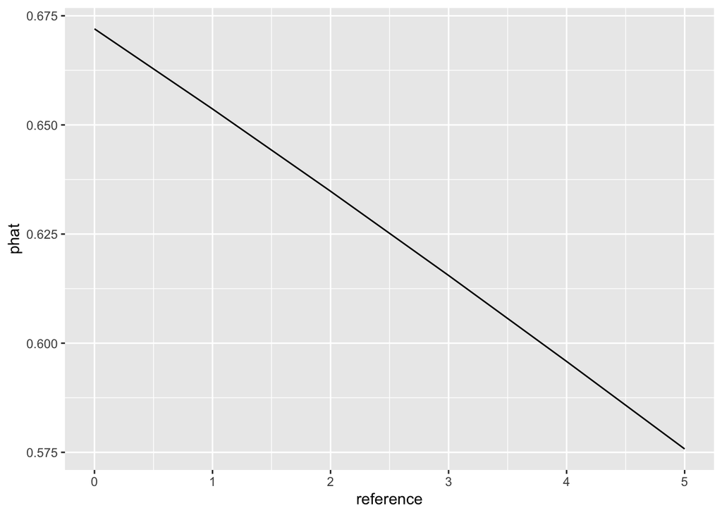

```r
pardepplot(log_model,pred.var="reference",data=bbb,hline=female.overall)
```

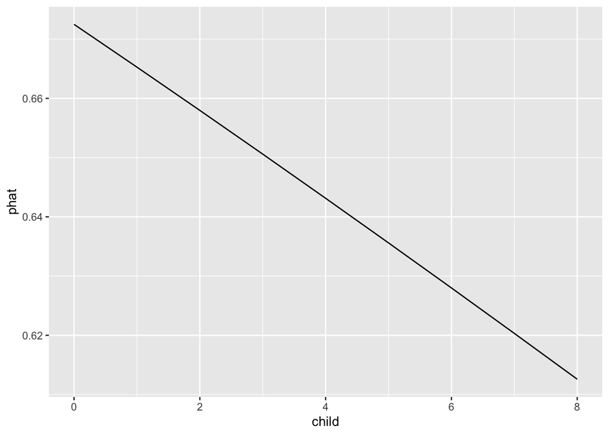

```r
pardepplot(log_model,pred.var="child",data=bbb,hline=female.overall)
```

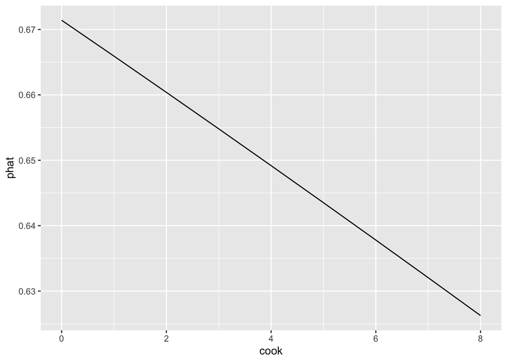

```r
pardepplot(log_model,pred.var="cook",data=bbb,hline=female.overall)
```